# Final Report

# Introduction

This project analyzes NHANES public health data to examine the relationship between body mass index (BMI), physical activity, sex, education level, height, and weight among adults in the United States.

The research question for this project is: **Is there a significant difference in BMI across physical activity levels among U.S. adults?**

The null hypothesis is that there is no significant difference in mean BMI across physical activity levels. The alternative hypothesis is that there is a significant difference in mean BMI across physical activity levels.

# Data Cleaning

The NHANES datasets were imported into RStudio and merged using the participant identification variable `SEQN`. The datasets included demographic data, body measurement data, and physical activity questionnaire data.

Relevant variables were selected, including age, sex, education level, BMI, height, weight, and physical activity variables. Missing values were removed, and invalid responses were filtered out. Categorical variables were recoded into readable labels such as Male, Female, Low Activity, Moderate Activity, and Vigorous Activity.

```r
library(haven)
library(dplyr)
```

```r
library(ggplot2)

demo <- read_xpt("../data/P_DEMO (5).xpt")
bmx  <- read_xpt("../data/P_BMX.xpt")
paq  <- read_xpt("../data/P_PAQ.xpt")

nhanes <- demo %>%
  inner_join(bmx, by = "SEQN") %>%
  inner_join(paq, by = "SEQN")

nhanes_clean <- nhanes %>%
  select(SEQN, RIAGENDR, RIDAGEYR, RIDRETH3, DMDEDUC2,
         BMXBMI, BMXWT, BMXHT, PAQ605, PAQ620, PAD680) %>%
  filter(RIDAGEYR >= 18) %>%
  filter(!is.na(BMXBMI),
         !is.na(BMXWT),
         !is.na(BMXHT),
         !is.na(PAQ605),
         !is.na(PAQ620),
         !is.na(PAD680)) %>%
  filter(RIAGENDR %in% c(1, 2),
         DMDEDUC2 %in% c(1, 2, 3, 4, 5),
         PAQ605 %in% c(1, 2),
         PAQ620 %in% c(1, 2)) %>%
  mutate(
    Sex = factor(RIAGENDR, levels = c(1, 2),
                 labels = c("Male", "Female")),
    Education = factor(DMDEDUC2,
                       levels = c(1, 2, 3, 4, 5),
                       labels = c("Less than 9th grade",
                                  "9th-11th grade",
                                  "High school graduate",
                                  "Some college/AA",
                                  "College graduate or above")),
    Activity_Level = case_when(
      PAQ605 == 1 ~ "Vigorous Activity",
      PAQ605 == 2 & PAQ620 == 1 ~ "Moderate Activity",
      PAQ605 == 2 & PAQ620 == 2 ~ "Low Activity"
    ),
    Activity_Level = factor(Activity_Level,
                            levels = c("Low Activity",
                                       "Moderate Activity",
                                       "Vigorous Activity"))
  )
```

# Descriptive Statistics

```r
nhanes_clean %>%
  summarise(
    Mean_BMI = mean(BMXBMI, na.rm = TRUE),
    Median_BMI = median(BMXBMI, na.rm = TRUE),
    SD_BMI = sd(BMXBMI, na.rm = TRUE),
    Mean_Age = mean(RIDAGEYR, na.rm = TRUE),
    Median_Age = median(RIDAGEYR, na.rm = TRUE),
    SD_Age = sd(RIDAGEYR, na.rm = TRUE),
    Mean_Weight = mean(BMXWT, na.rm = TRUE),
    Median_Weight = median(BMXWT, na.rm = TRUE),
    SD_Weight = sd(BMXWT, na.rm = TRUE)
  )
```

```
## # A tibble: 1 × 9
##   Mean_BMI Median_BMI SD_BMI Mean_Age Median_Age SD_Age Mean_Weight
##      <dbl>      <dbl>  <dbl>    <dbl>      <dbl>  <dbl>       <dbl>
## 1     30.0       28.8   7.57     50.8         52   17.5        83.7
## # ℹ 2 more variables: Median_Weight <dbl>, SD_Weight <dbl>
```

```r
table(nhanes_clean$Sex)
```

```
##
##   Male Female
##   4033   4309
```

```r
table(nhanes_clean$Education)
```

```
##
##       Less than 9th grade            9th-11th grade      High school graduate
##                       635                       913                      2015
##           Some college/AA College graduate or above
##                      2721                      2058
```

```r
table(nhanes_clean$Activity_Level)
```

```
##
##      Low Activity Moderate Activity Vigorous Activity
##              4342              1897              2103
```

# Visualizations

## Visualization 1: Height and Weight by Physical Activity Level

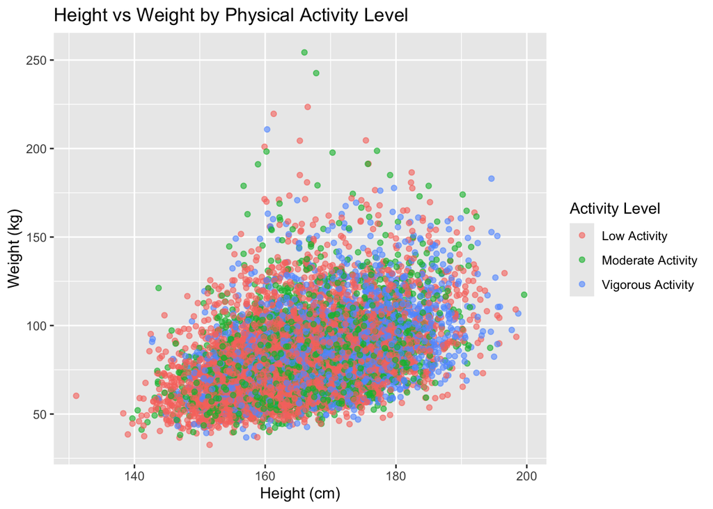

```r
ggplot(
  nhanes_clean,
  aes(x = BMXHT, y = BMXWT, color = Activity_Level)
) +
  geom_point(alpha = 0.6) +
  labs(
    title = "Height vs Weight by Physical Activity Level",
    x = "Height (cm)",
    y = "Weight (kg)",
    color = "Activity Level"
  )
```

This scatterplot shows the relationship between height and weight while also displaying differences by physical activity level.

## Visualization 2: BMI Distribution by Physical Activity Level

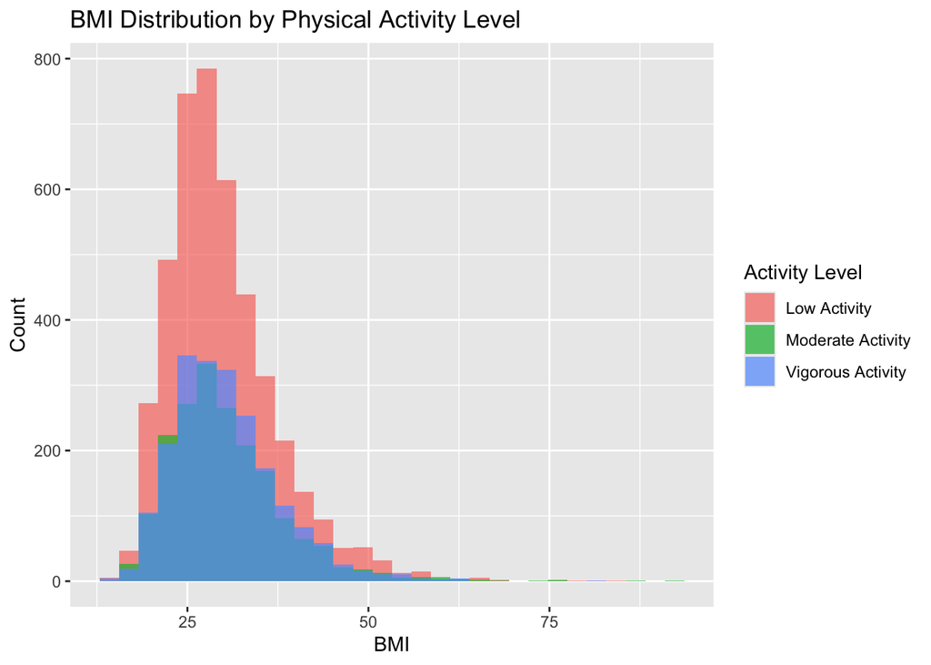

```r
ggplot(
  nhanes_clean,
  aes(x = BMXBMI, fill = Activity_Level)
) +
  geom_histogram(bins = 30, alpha = 0.7, position = "identity") +
  labs(
    title = "BMI Distribution by Physical Activity Level",
    x = "BMI",
    y = "Count",
    fill = "Activity Level"
  )
```

This histogram shows how BMI values are distributed across different physical activity levels.

## Visualization 3: BMI by Physical Activity Level

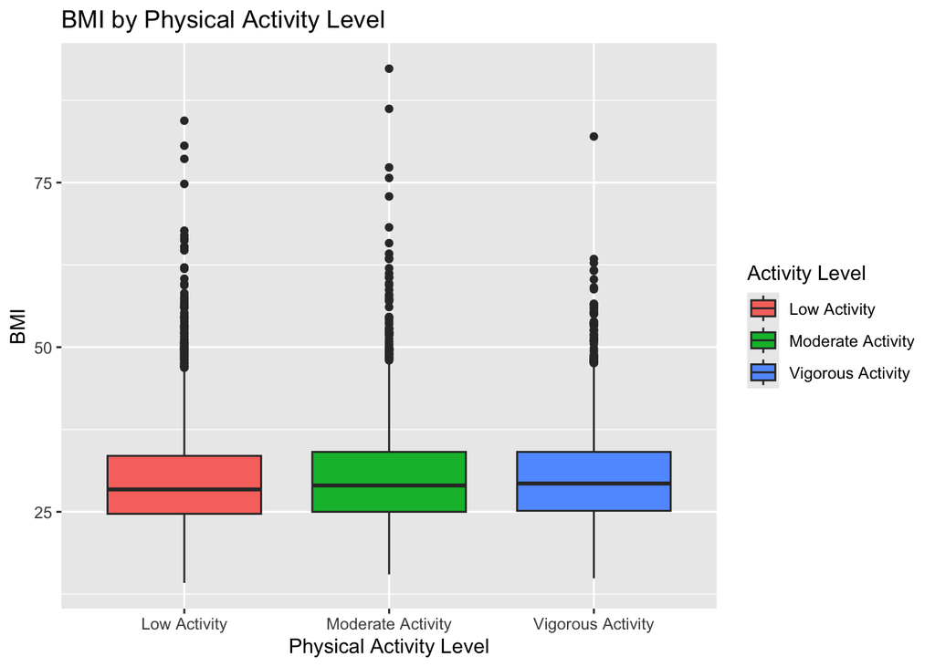

```r
ggplot(
  nhanes_clean,
  aes(x = Activity_Level, y = BMXBMI, fill = Activity_Level)
) +
  geom_boxplot() +
  labs(
    title = "BMI by Physical Activity Level",
    x = "Physical Activity Level",
    y = "BMI",
    fill = "Activity Level"
  )
```

This boxplot compares BMI values across low, moderate, and vigorous activity groups.

## Visualization 4: BMI by Activity Level and Sex

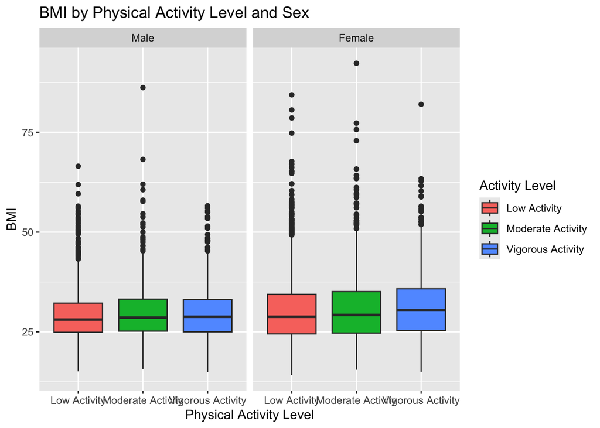

```r
ggplot(
  nhanes_clean,
  aes(x = Activity_Level, y = BMXBMI, fill = Activity_Level)
) +
  geom_boxplot() +
  facet_wrap(~ Sex) +
  labs(
    title = "BMI by Physical Activity Level and Sex",
    x = "Physical Activity Level",
    y = "BMI",
    fill = "Activity Level"
  )
```

This multivariate visualization compares BMI across activity levels while separating results by sex.

# Inferential Statistics

A one-way ANOVA test was used to compare mean BMI across the three physical activity groups.

```r
anova_result <- aov(BMXBMI ~ Activity_Level, data = nhanes_clean)

summary(anova_result)
```

```
##                  Df Sum Sq Mean Sq F value  Pr(>F)
## Activity_Level    2    564  281.93    4.92 0.00732 **
## Residuals      8339 477888   57.31
## ---
## Signif. codes:  0 '***' 0.001 '**' 0.01 '*' 0.05 '.' 0.1 ' ' 1
```

```r
TukeyHSD(anova_result)
```

```
##   Tukey multiple comparisons of means
##     95% family-wise confidence level
##
## Fit: aov(formula = BMXBMI ~ Activity_Level, data = nhanes_clean)
##
## $Activity_Level
##                                            diff         lwr       upr     p adj
## Moderate Activity-Low Activity       0.54173176  0.05334370 1.0301198 0.0252935
## Vigorous Activity-Low Activity       0.49962398  0.02817681 0.9710712 0.0347265
## Vigorous Activity-Moderate Activity -0.04210778 -0.60401267 0.5197971 0.9831325
```

The ANOVA test was used because BMI is a quantitative variable and physical activity level has three categories. This test helps determine whether mean BMI differs significantly across the activity groups.

# Multivariate Analysis

```r
library(psych)
```

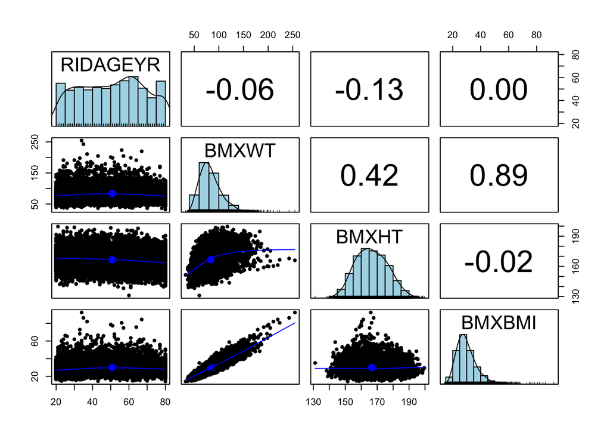

```r
pairs.panels(
  nhanes_clean[, c("RIDAGEYR", "BMXWT", "BMXHT", "BMXBMI")],
  method = "pearson",
  hist.col = "lightblue",
  density = TRUE,
  ellipses = TRUE
)
```

The multivariate correlation plot shows relationships among age, weight, height, and BMI.

# Discussion

One limitation of this project is that NHANES data are cross-sectional, meaning the results show associations but cannot prove cause and effect. Another limitation is that physical activity responses may be self-reported, which can lead to reporting bias.

# Conclusion

This project used NHANES data and RStudio to analyze the relationship between BMI and physical activity levels among U.S. adults. The project included data cleaning, descriptive statistics, visualizations, ANOVA testing, and multivariate analysis.

Overall, the results suggest that physical activity level is related to BMI. The project demonstrates how public health data can be cleaned, analyzed, visualized, and interpreted using R.